# SA24204163

KaiLi Wang

2023-12-08

### 可见性图(visibility)

可见性图算法将时间序列映射到网络中，并且该网络继承了时间序列的一些特征。考虑一个长度为$N$的时间序列$X(t)$，如果对应的数据之间存在可见性，也就是说，如果存在一条直线连接序列数据，且这条“可见性线”不与任何中间数据高度相交，则两个节点相连。更准确地说，两个任意数据值$(t_i, x(t_i))$和$(t_j,x(t_j))$具有可见性，可以成为连接性图的两个连接节点，若它们之间任何其他数据$(t_k,x(t_k))$, $(t_i<t_k<t_j)$满足
$$\begin{equation}
x(t_k)<x(t_i)+(x(t_j)-x(t_i))\frac{t_k-t_i}{t_j-t_i},\quad 1\le
t_i<t_k< t_j\le N .
\end{equation}$$

源代码如下,visibility函数可以将一个时间序列根据可见性图算法转换为网络图，具体返回图的邻接矩阵

```r
visibility<-function(data,m){
  graph<-matrix(0,length(data),length(data))
  if(length((data))==2){
    graph<-matrix(c(0,1,1,0),2,2)
    return(graph)
  }
  for (i in 1:(length(data)-2)) {
    for(j in (i+2):(min((i+2+m),length(data)))){
      a<-0
      for(k in (i+1):(j-1)){
        b<-(data[i]+(data[j]-data[i])*(k-i)/(j-i))
        if((data[k]<b)){
          a<-a
        }else{
          a<-a+1
        }
      }
      if(a==0){
        graph[i,j]<-1
      }else{
        graph[i,j]<-0
      }
    }

  }
  for(i in 1:(length(data)-1)){
    graph[i,i+1]<-1
  }
  graph<-graph+t(graph)
  return(graph)
}
```

为了更直观地说明，用柱状图绘制了下表中20个数据的周期性时间序列，其中红色的线表示节点之间存在可见性关系

| 1 | 2 | 3 | 4 | 5 | 6 | 7 | 8 | 9 | 10 | 11 | 12 | 13 | 14 | 15 | 16 | 17 | 18 | 19 | 20 |
| --- | --- | --- | --- | --- | --- | --- | --- | --- | --- | --- | --- | --- | --- | --- | --- | --- | --- | --- | --- |
| 0.87 | 0.49 | 0.36 | 0.83 | 0.87 | 0.49 | 0.36 | 0.83 | 0.87 | 0.49 | 0.36 | 0.83 | 0.87 | 0.49 | 0.36 | 0.83 | 0.87 | 0.49 | 0.36 | 0.83 |

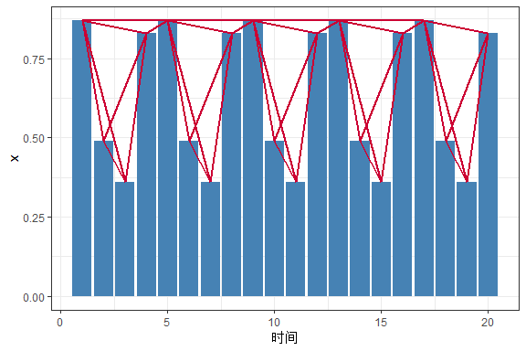

```r
library(ggplot2)
x<-c(0.87,0.49,0.36,0.83,0.87,0.49,0.36,0.83,0.87,0.49,0.36,0.83,0.87,0.49,0.36,0.83,0.87,0.49,0.36,0.83)
data <- data.frame(id = 1:20, x =x)
p <- ggplot(data, aes(x = id, y = x)) +
  geom_bar(stat = "identity", fill = "steelblue") +
  theme_minimal()
segments1 <- data.frame(
  x = data$id[1:19],
  y = data$x[1:19],
  xend = data$id[2:20],
  yend = data$x[2:20]
)
segments2<-data.frame(
  x=data$id[c(1,1,1,2,5,5,5,6,9,9,9,10,13,13,13,14,17,17,18)],
  y=data$x[c(1,1,1,2,5,5,5,6,9,9,9,10,13,13,13,14,17,17,18)],
  xend=data$id[c(3,4,5,4,7,8,9,8,11,12,13,12,15,16,17,16,19,20,20)],
  yend=data$x[c(3,4,5,4,7,8,9,8,11,12,13,12,15,16,17,16,19,20,20)])
p <- p + geom_segment(data = segments1, aes(x = x, y = y, xend = xend, yend = yend), linewidth = 0.8, color = "#CC0033")
p <- p + geom_segment(data = segments2, aes(x = x, y = y, xend = xend, yend = yend), linewidth = 0.8, color = "#CC0033")
p <- p + theme_bw() + xlab("时间")
print(p)
```

下面是利用可见性图算法将时间序列转换为的网络图

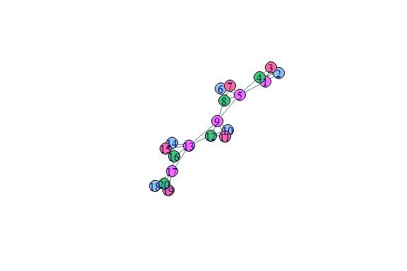

```r
library(igraph)
g<-graph_from_adjacency_matrix(visibility(x,100), mode = "undirected")
V(g)$color <- c(rep(c("#FF66FF","#88c4e8","#FF6699","#33CC66"),5))
E(g)$color <- "steelblue"
plot(g, vertex.label = V(g)$name, vertex.size =20, vertex.label.cex =1)
```

### 逆向度度量(BDM)

图中第$i$个节点的一种经典度量$d_i=\sum_{j\in V}a_{ij}$，计算了邻接矩阵第$i$行或列的加和，但这种度量既考虑了第$i$个节点与前面节点的连接性，又考虑了与它后面节点的连接性，对于正在进行中的时间序列来说，最新的时间序列点只有与前面节点的连接性，所以考虑使用逆向度度量BDM，便于时间序列变点的在线检测，同时对变点的离线检测也有比较好的效果。
$$\begin{equation}
{\mbox{BDM}_i}=\sum_{j<i}a_{ij}\label{3} .
\nonumber
\end{equation}$$

使用Cpp写的源代码如下,函数BDM可以利用一个图的邻接矩阵计算该图的逆向度度量

```r
library(Rcpp)
cppFunction('NumericVector BDM(NumericMatrix graph) {
   int m = graph.ncol();
   NumericVector backward_degree(m, 0.0);

   for (int i = 0; i < m; ++i) {
     for (int j = 0; j <= i; ++j) {
       backward_degree[i] += graph(i, j);
     }
   }
   return backward_degree;
}')
print(BDM(visibility(x,100)))
```

```
##  [1] 0 1 2 3 2 1 2 3 2 1 2 3 2 1 2 3 2 1 2 3
```

| 节点 | 1 | 2 | 3 | 4 | 5 | 6 | 7 | 8 | 9 | 10 | 11 | 12 | 13 | 14 | 15 | 16 | 17 | 18 | 19 | 20 |
| --- | --- | --- | --- | --- | --- | --- | --- | --- | --- | --- | --- | --- | --- | --- | --- | --- | --- | --- | --- | --- |
| BDM | 0 | 1 | 2 | 3 | 2 | 1 | 2 | 3 | 2 | 1 | 2 | 3 | 2 | 1 | 2 | 3 | 2 | 1 | 2 | 3 |

### 滑动平均值(MOVmean)

源代码如下，该函数输入一个向量data和滑动平均窗口大小n，返回该向量以n为窗口的滑动平均值

```r
MOVmean<-function(data,n){
  mean<-rep(0,length(data))
  if(n==1){
    mean<-data
  }else if(n==2){
    for(i in 1:(n/2)){
      mean[i]<-data[i]
    }
    for(i in (n/2+1):(length(data)-n/2+1)){
      mean[i]<-mean(data[(i-n/2):(i+n/2-1)])
    }
  }else if((n>2)&(n%%2==0)){
    for(i in 1:(n/2)){
      mean[i]<-mean(data[1:(i+n/2-1)])
    }
    for(i in (n/2+1):(length(data)-n/2+1)){
      mean[i]<-mean(data[(i-n/2):(i+n/2-1)])
    }
    for(i in (length(data)-n/2+2):length(data)){
      mean[i]<-mean(data[(i-n/2):length(data)])
    }
  }else {
    n2<-floor(n/2)
    n1<-ceiling(n/2)
    for(i in 1:n2){
      mean[i]<-mean(data[1:(i+n2)])
    }
    for(i in (n2+1):(length(data)-n2)){
      mean[i]<-mean(data[(i-n2):(i+n2)])
    }
    for(i in (length(data)-n2+1):length(data)){
      mean[i]<-mean(data[(i-n2):length(data)])
    }
  }
  return(mean)
}
```

### 滑动标准差(MOVsd)

源代码如下，该函数输入一个向量data和滑动平均窗口大小n，返回该向量以n为窗口的滑动标准差

```r
MOVsd<-function(data,n){
  sd<-rep(0,length(data))
  if(n==1){
    sd<-rep(0,length(data))
  }else if(n==2){
    for(i in 1:(n/2)){
      sd[i]<-0
    }
    for(i in (n/2+1):(length(data)-n/2+1)){
      sd[i]<-sd(data[(i-n/2):(i+n/2-1)])
    }
  }else if((n>2)&(n%%2==0)){
    for(i in 1:(n/2)){
      sd[i]<-sd(data[1:(i+n/2-1)])
    }
    for(i in (n/2+1):(length(data)-n/2+1)){
      sd[i]<-sd(data[(i-n/2):(i+n/2-1)])
    }
    for(i in (length(data)-n/2+2):length(data)){
      sd[i]<-sd(data[(i-n/2):length(data)])
    }
  }else{
    n2<-floor(n/2)
    n1<-ceiling(n/2)
    for(i in 1:n2){
      sd[i]<-sd(data[1:(i+n2)])
    }
    for(i in (n2+1):(length(data)-n2)){
      sd[i]<-sd(data[(i-n2):(i+n2)])
    }
    for(i in (length(data)-n2+1):length(data)){
      sd[i]<-sd(data[(i-n2):length(data)])
    }
  }
  return(sd)
}
```

### 变点检测(changepoint)

用逆向度度量检测时间序列变点的具体步骤。

第一步，考虑一个长度为$N$的时间序列$X(t)$，首先对该时间序列进行差分得到$DX(t)$，然后使用$DX(t)$的绝对值$|{DX(t)}|$来检测增加的变点，使用$DX(t)$的负值(正值赋值为零)$\min\{{{DX(t)},0}\}$来检测减少的变点。

第二步，基于可见性算法或滑动窗口可见性算法将时间序列转换成图，其中时间序列的每个值都映射到与时间序列顺序相同的节点上。若任意两个节点$(t_i, x(t_i))$和$(t_j,x(t_j))$之间的任意一点$(t_k,x(t_k))$, $(t_i<t_k<t_j)$都满足$x(t_k)<x(t_i)+(x(t_j)-x(t_i))\frac{t_k-t_i}{t_j-t_i}$，则可以在相应数据之间绘制可见线。易知相邻的结点具有可见性。

第三步，计算图的每个节点的逆向度度量BDM，考虑每个节点与其前面所有节点连接的总和，${\mbox{BDM}_i}=\sum_{j<i}a_{ij}$，突变点作为差分后$DX(t)$序列的一个高峰(hub)，在转化为图的过程中更容易与周围的点建立可见性关系，往往有更大的逆向度度量。

第四步，计算逆向度度量序列在长度为$n$的窗口上的滑动平均值和滑动标准差。参数$n$是唯一的参数，它取决于时间序列可观测值的性质。定义逆向度度量指标BDI为逆向度度量BDM的以$n$为窗口的滑动平均值$\mu_{i}^{\mathrm{MA}}$和滑动标准差$\sigma_{i}^{\mathrm{MA}}$的加和，即$\mbox{BDI}_i=\mu_{i}^{\mathrm{MA}}+\sigma_{i}^{\mathrm{MA}}$。

第五步，最后，类似于置信区间的构造，当一点的逆向度度量指标BDI大于BDIquat，即BDI的平均值加上两倍的BDI标准差时，该点为突变点，反之则不是突变点。

源代码如下，该函数综合了上面几个函数，输入时间序列，滑动平均窗口大小ni，检测增点(increase=1)还是检测降点(increase=2)，窗口大小(默认值m=250),就可以进行变点检测，返回一个list，包含(“BDM”,“movmean”,“movsd”,“BDI”,“BDIquant”,“test”,“figure”)，可以具体查看

```r
changepoint<-function(D,ni,increase,m=250){
  z<-D
  D<-diff(D)
  if(increase==1){
    for(i in 1:length(D)){
      if(D[i]<0){
        D[i]=-D[i]
      }
    }
  }else{
    for(i in 1:length(D)){
      if(D[i]>0){
        D[i]=0
      }else{
        D[i]=-D[i]
      }
    }
  }
  #plot(D,type='l')
  Net_test<-visibility (D,m)
  #print(Net_test)
  #backward network degree
  Net_Degree_test=BDM(Net_test)
  #plot(Net_Degree_test,type = 'l')
  #moving mean of backward degree time series
  MA2test=MOVmean(Net_Degree_test,ni)
  #moving std of backward degree time series
  MStd2test=MOVsd(Net_Degree_test,ni)
  #BDI
  MA2MStd2test=MA2test+MStd2test
  BDIquant<-(mean(MA2MStd2test)+2*sd(MA2MStd2test))
  t<-rep(0,length(MA2MStd2test))
  for(i in 1:length(MA2MStd2test)){
    if(MA2MStd2test[i]>BDIquant){
      t[i]<-1
    }
  }
  data1<-data.frame("time1"=1:length(z),z,"test1"=c(t,0))
  p<-ggplot(data=data1,aes(x=time1, y = z,color=test1)) + geom_point() +
    geom_line()+theme_bw()+ggtitle("changepoint") + theme(plot.title = element_text(hjust = 0.5))
  list<-list(Net_Degree_test,MA2test,MStd2test,MA2MStd2test,BDIquant,t,p)
  names(list)<-c("BDM","movmean","movsd","BDI","BDIquant","test","figure")
  return(list)
}
```

### 模型1

在正态随机分布的时间序列中间构造一个先突然增加，然后突然减少的突变区域

$$\begin{equation}
x_{t}=\begin{cases}
\epsilon_t \qquad \qquad t=\ 1,2,...,90\\
{(\frac{t-90}{6})}^4+\epsilon_t \qquad t=\ 91,92,...,99 \\
{(\frac{112-t}{8})}^4+\epsilon_t \qquad t=\ 100,101,...,111 \\
\epsilon_t \qquad \qquad t=\ 112,113,...,200 .\end{cases} \label{4}
\nonumber
\end{equation}$$
其中$\epsilon_t$为均值为0，标准差为0.3的正态随机变量

```r
set.seed(1234)
x<-c()
  for(i in 1:90){
    x<-c(x,rnorm(1,0,0.3))
  }
  for(i in 91:99){
    x<-c(x,((i-90)/6)^(4)+rnorm(1,0,0.3))
  }
  for(i in 100:111){
    x<-c(x,((112-i)/8)^4+rnorm(1,0,0.3))
  }
  for(i in 112:200){
    x<-c(x,rnorm(1,0,0.3))
  }
  a1<-changepoint(x,8,1)
  a1
```

```
## $BDM
##   [1]  0  1  2  1  1  2  1  3  5  4  5  3  7  4  5  1  2  2 13  1  1  2  4  4  2
##  [26]  6  1  1  3  6  1  1  2  4  1  4  1  5  1  9 10  1  2  2  1  3  3  5  1  5
##  [51]  2  1  2  4  2  5  9  1  7  1  2  3  1  2  3  9  1  1  2  2  3  2  6  6  7
##  [76]  1  2  3  2  1  4  6  3  1  1  2  5  1  5  6  1 10  1  2 14  1 26  6  1 11
## [101]  1  1  3  3  1  5  1  3  5  4  7  7 10  1  2  7  1  1  3  1  4 12  1  2  3
## [126]  1  2  3  3  3  4  8  8 11  1  1  3  7  1  2  3  1  2  3  1  6  3  1  2  3
## [151]  1  7 12  1  2  3  1  2  3  4  5  1  4  6  1  8 11  1  5  1  3  1  2 15  1
## [176]  1 17  1  1  3  2  1  2  3  4  3  6  1  2  1  9  1  1  3  3  1  5  1 10
##
## $movmean
##   [1] 1.000000 1.000000 1.166667 1.142857 1.375000 2.000000 2.375000 2.750000
##   [9] 3.000000 3.750000 4.000000 4.500000 4.250000 3.875000 3.625000 4.625000
##  [17] 4.375000 3.625000 3.375000 3.250000 3.625000 3.625000 4.125000 2.625000
##  [25] 2.625000 2.875000 3.375000 3.000000 2.625000 2.625000 2.375000 2.375000
```

[output cut: 96 more lines]

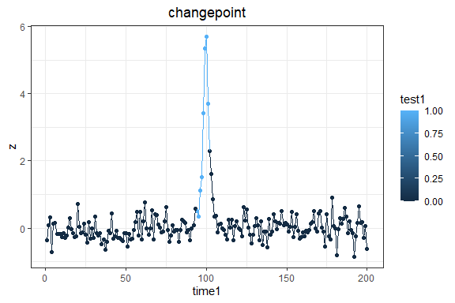

```r
  a2<-changepoint(x,6,2)
  a2
```

```
## $BDM
##   [1]  0  1  2  1  2  3  1  3  4  2  4  1  3  3  7  1  2  1  3 10  1  2  3  4  1
##  [26]  1  4  1  2  1  5  1  2  3  1  3  1  2  3  2 10  1  2  3  1  3  3  3  4  7
##  [51]  1  2  1  3  3  3  9  1  7  1  2  3  1  2  3  8  1  2  3  1  3  2  4  4  7
##  [76]  1  1  3  4  1  3  5  1  2  3  2  6  1  4  1  2  2  4  5  1  2  2  2  2 27
## [101]  1  1  3  3  1  5  1  3  5  4  6  6  2  8  1 12  1  2  3  1  3  1  6  1  7
## [126]  1  2  1  2  3  6  7  1 10  1  2  3  1  3  1  2  3  2  1  2  2  9  1  2  3
## [151]  1  2 14  1  2  3  1  1  3  5  1  4  3  6  6  6 11  1  2  3  6  1  2  1  8
## [176]  1  2 12  1  2  1  2  3  2  3  4  5  1  2  1  6  1  2  2  4  1  3  1  7
##
## $movmean
##   [1] 1.000000 1.000000 1.200000 1.500000 1.666667 2.000000 2.333333 2.500000
##   [9] 2.833333 2.500000 2.833333 2.833333 3.333333 3.166667 2.833333 2.833333
##  [17] 2.833333 4.000000 3.000000 3.166667 3.333333 3.833333 3.500000 2.000000
##  [25] 2.500000 2.333333 2.166667 1.666667 2.333333 2.333333 2.000000 2.333333
```

[output cut: 101 more lines]

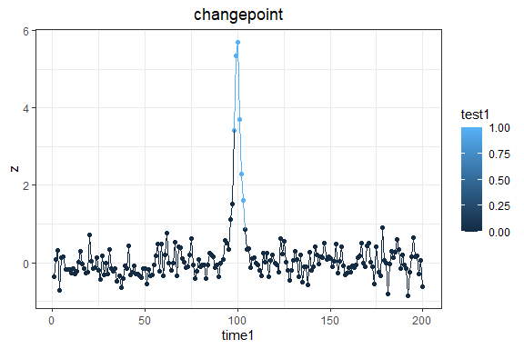

### 模型2

第二类时间序列模型是在AR模型的基础上添加明显的突增点或突减点
$$\begin{align}
x_t=0.6x_{t-1}-0.5x_{t-2}+\epsilon_t+ f(\left\lfloor
\frac{t-1}{500}\right\rfloor ),\quad t=3,...,5000 .\tag{A}\label{9A}
\nonumber
\end{align}$$

### 算法改进

考虑一个长度为$N$的时间序列$X(t)$，可见性图基本算法的时间复杂度为$O(N^3)$，这是因为要判断每对节点的可见性关系，就要对这两个节点中间的每一个节点都检查一次是否满足可见性关系。当时间序列的节点数变得很大时，计算可见性图所需的时间就会大大增加，这时可以使用滑动窗口可见性图(SVG)，，当第$t_i$点和第$t_j$点距离很远时($|t_i-t_j|$很大)，让它们中间每一个点的值都在$(t_i, x(t_i))$和$(t_j,x(t_j))$的连线下面是很困难的，即当邻接矩阵的第$ij$个元素远离主对角线时，它往往是0。

滑动窗口可见性图算法的基本原理是取一组长度为$W$的窗口，每次只检查窗口(Window)内每对点的可见性关系，然后将该窗口逐步移动到时间序列的末尾。该方法将长度为$N$的时间序列转化为图的时间复杂度为$O(W^2N)$，当$W$远小于N时,大大减少了程序运行时间，changepoint函数里面，窗口的默认大小为250，可以根据实际需求更改

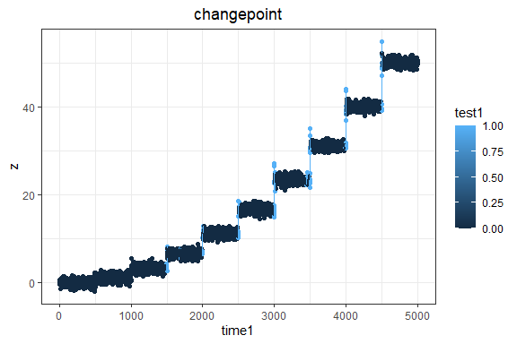

```r
set.seed(1)
y<-rep(0,5000)
epi<-rnorm(5000,0,0.5)
deltay<-c(rep(0,500),rep(1,500),rep(3,500),rep(6,500),rep(10,500),rep(15,500),rep(21,500),rep(28,500),rep(36,500),rep(45,500))
for(i in 3:5000){
  y[i]<-0.6*y[i-1]-0.5*y[i-2]+epi[i]+deltay[i]
}
a<-changepoint(y,15,1)
a$figure
```